# General figures

Christian Diener

# Clinical data

```r
library(mbtools)
library(ggplot2)
theme_set(theme_classic())
status_map <- c("NG", "IFG", "IGT", "IFG+ITG", "T2D", "T2D treated")
ps <- readRDS("../data/taxonomy_clean.rds")
meta <- as.data.table(as(sample_data(ps), "data.frame"))
meta <- meta[, !grepl("months", names(meta)), with = FALSE]
meta[, diabetes_status := factor(status_map[diabetes_status],
                                 levels = status_map)]
```

### Population design

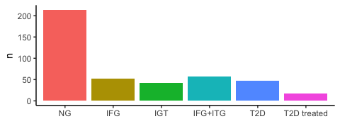

```r
counts <- meta[order(diabetes_status), .N, by = diabetes_status]
ggplot(counts, aes(x = diabetes_status, y = N, fill = diabetes_status)) +
  geom_bar(stat = "identity") + guides(fill = F) +
  labs(x = "", y = "n")
```

```r
ggsave("population.svg", width = 5, height = 2)
```

### Correlations between clinical variables

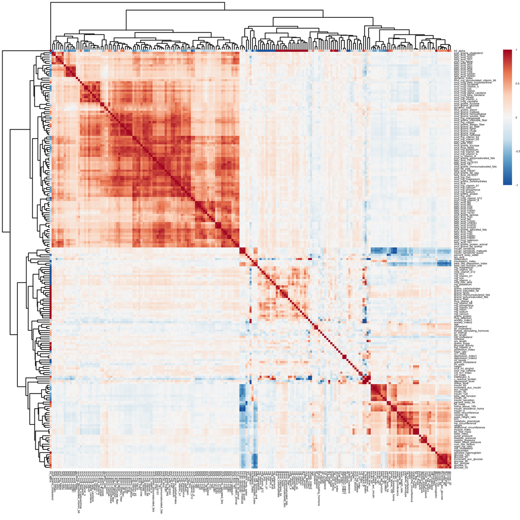

```r
library(pheatmap)
corrs <- cor(meta[, sapply(meta, is.numeric), with=F], method="spearman", use="pairwise.complete.obs")
colors <- colorRampPalette(rev(RColorBrewer::brewer.pal(n = 7, name = "RdBu")))(128)
pheatmap(corrs, col=colors, border_color=NA, filename="cors.png", fontsize=3,
         width=8, height=8)
knitr::include_graphics("cors.png")
```

```r
rich_corrs <- sort(corrs["richness", ])
data <- meta[, sapply(meta, is.numeric), with=F]
pearson_stats <- function(x) {
  test <- cor.test(data$richness, x, method="spearman", exact=F, continuity=T)
  return(c(test$estimate, pval=test$p.value))
}
pearson <- as.data.frame(t(apply(data, 2, pearson_stats)))
pearson$fdr <- p.adjust(pearson$pval, method="fdr")
pearson[order(pearson$pval), ]
```

|  | rho | pval | fdr |
| --- | --- | --- | --- |
| richness | 1.00000000 | 0.000000000 | 0.0000000 |
| fatty_acid_f22691 | 0.15706542 | 0.002106232 | 0.2095701 |
| fatty_acid_f20591 | 0.12623353 | 0.013672407 | 0.4182357 |
| bmi | -0.11699879 | 0.015206776 | 0.4182357 |
| muscle_mass | -0.12936395 | 0.020424854 | 0.4182357 |
| snut_mcg_carotene | 0.11731418 | 0.022005503 | 0.4182357 |
| heart_rate | -0.15078302 | 0.024653758 | 0.4182357 |
| metabolic_phenotype | -0.10871057 | 0.026980353 | 0.4182357 |
| percent_body_fat | -0.10688385 | 0.027028968 | 0.4182357 |
| snut_mcg_luts | 0.11187939 | 0.029000163 | 0.4182357 |

[output cut: 90 more lines]

### Relationship between diabetes and obesity

Number of phenotype variables used:

```r
ncol(meta) - 1  # have to subtract the ID column
```

```
[1] 227
```

Distribution of groups:

```r
table(meta$diabetes_status)
```

```
         NG         IFG         IGT     IFG+ITG         T2D T2D treated
        214          52          42          57          48          17
```

Previous metformin treatment/consumption:

```r
table(meta$metformin == 0, meta$diabetes_status)
```

```
         NG IFG IGT IFG+ITG T2D T2D treated
  FALSE   1   2   3       1   4          14
  TRUE  213  50  39      56  44           3
```

BMI raises slightly with group. Treated patients seem to have lost weight again.

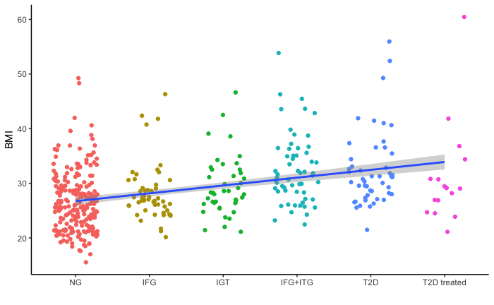

```r
pl <- ggplot(meta, aes(x=diabetes_status, y=bmi, col=diabetes_status)) + geom_jitter(width=0.3) +
  geom_smooth(method="glm", aes(group=0, x=as.numeric(diabetes_status))) +
  guides(color=FALSE) + labs(x="", y="BMI")
ggsave("status_vs_bmi.svg", width=6, height=4)
pl
```

Pretty clear association between BMI and area under the glucose curve, however there is no clear BMI (vertical line) to separate healthy from diabetic.

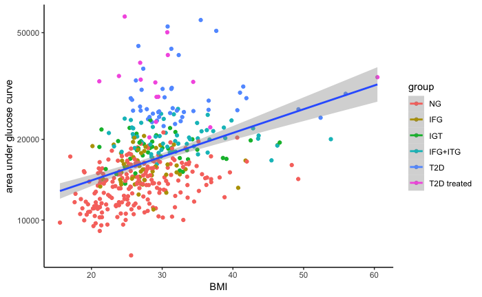

```r
pl <- ggplot(meta, aes(x=bmi, y=auc_glucose, col=diabetes_status)) + geom_point() +
  geom_smooth(method="glm", aes(group=0)) + scale_y_log10(breaks=c(5000, 10000, 20000, 50000)) +
  labs(x="BMI", y="area under glucose curve", color="group")
ggsave("auc_vs_bmi.svg", width=6, height=4)
pl
```

Visceral fat also associates with the area under the glucose curve. The same for percent body fat, but with a lower Spearman correlation (0.5 vs 0.3).

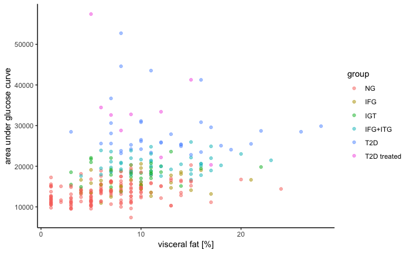

```r
pl <- ggplot(meta, aes(x=visceral_fat, y=auc_glucose, col=diabetes_status)) + geom_point(alpha=0.5) +
  labs(x="visceral fat [%]", y="area under glucose curve", color="group")
ggsave("fat_vs_auc.svg", width=6, height=4)
pl
```

Correlations:

```r
print(cor.test(~ as.numeric(diabetes_status) + bmi, data=meta, method="spearman"))
```

```
Cannot compute exact p-value with ties
```

```
    Spearman's rank correlation rho

data:  as.numeric(diabetes_status) and bmi
S = 8162600, p-value < 2.2e-16
alternative hypothesis: true rho is not equal to 0
sample estimates:
     rho
0.384006
```

```r
print(cor.test(~ auc_glucose + bmi, data=meta, method="spearman"))
```

```
Cannot compute exact p-value with ties
```

```
    Spearman's rank correlation rho

data:  auc_glucose and bmi
S = 6898300, p-value < 2.2e-16
alternative hypothesis: true rho is not equal to 0
sample estimates:
      rho
0.4570027
```

```r
print(cor.test(~ auc_glucose + visceral_fat, data=meta, method="spearman"))
```

```
Cannot compute exact p-value with ties
```

```
    Spearman's rank correlation rho

data:  auc_glucose and visceral_fat
S = 2612200, p-value < 2.2e-16
alternative hypothesis: true rho is not equal to 0
sample estimates:
      rho
0.5125988
```

### Glucose and insulin curves

Pretty straight forward. We have pretty good information desnity especially in the early onset.

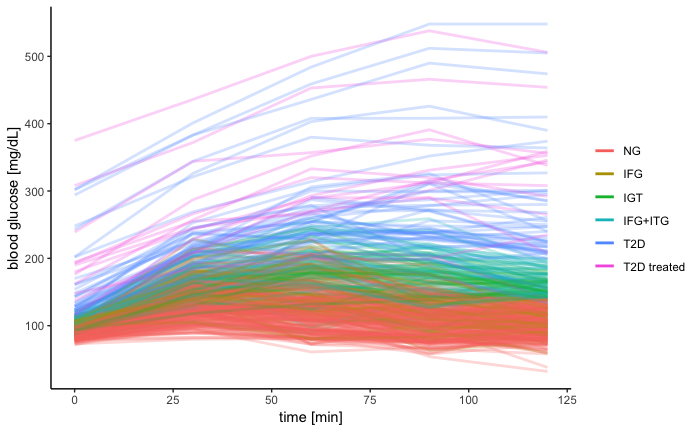

```r
cols <- c(paste0("glucose_", seq(0, 121, 30)), "id", "diabetes_status")
glc <- meta[ , ..cols]
glc <- melt(glc, c("id", "diabetes_status"), variable.name="time",
            value.name="glucose")
glc[, time := as.numeric(tstrsplit(time, "_")[[2]])]
pl <- ggplot(glc, aes(x=time, y=glucose, col=diabetes_status, group=id)) +
      geom_line(alpha=0.25, lwd=1) + guides(colour = guide_legend(override.aes = list(alpha = 1))) +
      labs(color="", x="time [min]", y="blood glucose [mg/dL]")
ggsave("glucose_curves.svg", width=6, height=4)
pl
```

insulin curver better colored by beta cell function since there is no clear pattern when by group.

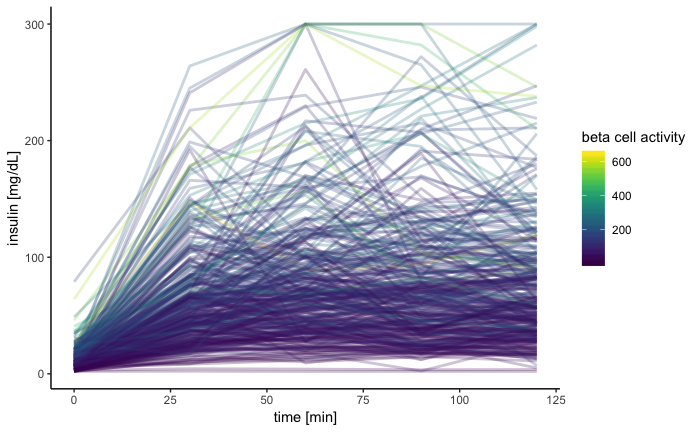

```r
cols <- c(paste0("insulin_", seq(0, 121, 30)), "id", "beta_cell_function")
ins <- meta[ , ..cols]
ins <- melt(ins, c("id", "beta_cell_function"), variable.name="time",
            value.name="insulin")
ins[, time := as.numeric(tstrsplit(time, "_")[[2]])]
pl <- ggplot(ins, aes(x=time, y=insulin, col=beta_cell_function, group=id)) +
      geom_line(alpha=0.25, lwd=1) +
      labs(color="beta cell activity", x="time [min]", y="insulin [mg/dL]") + viridis::scale_color_viridis()
ggsave("insuline_curves.svg", width=6, height=4)
pl
```

## Microbiome data

Number of unique sequence variants:

```r
nrow(tax_table(ps))
```

```
[1] 17059
```

per sample:

```r
present <- apply(otu_table(ps), 1, function(x) sum(x > 0))
print(c(mean(present), sd(present)))
```

```
[1] 327.50465  99.47578
```

Genera:

```r
uniqueN(tax_table(ps)[, "Genus"])
```

```
[1] 379
```

Ordination plot shows pretty mixed signal. The same for DCA or t-SNE.

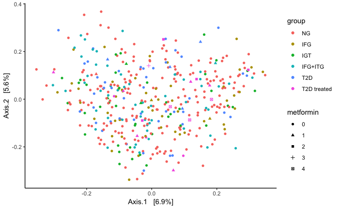

```r
sdata <- as.data.frame(meta)
rownames(sdata) <- sample_names(ps)
sample_data(ps) <- sdata
ord <- ordinate(ps, method="PCoA")
plot_ordination(ps, ord, color="diabetes_status", shape = "metformin") + labs(color="group")
ggsave("ordination.svg", width=6, height=4)
```

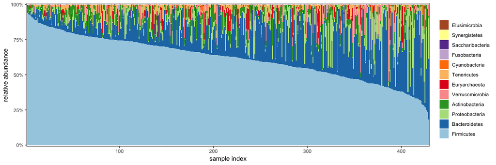

```r
pl <- plot_taxa(ps, show_samples = FALSE)
ggsave("phylum_bars.png", width=12, height=4, dpi=200)
pl
```

PERMANOVA:

```r
perm <- readRDS("../data/permanova.rds")
# Explained variance
r2s <- perm$aov.tab
```

Explained variance in Bray-Curtis with a p value cutoff of 0.05 for the coefficients:

```r
sum(r2s[r2s[, 6] < 0.05, 5], na.rm=T)
```

```
[1] 0.08915948
```

Explained variance in Bray-Curtis with a p value cutoff of 0.1 for the coefficients:

```r
sum(r2s[r2s[, 6] < 0.1, 5], na.rm=T)
```

```
[1] 0.1403164
```